# A quick glance at reported robberies in Mexico City’s transportation system

# Data cleaning

The objective of this section is to work towards a data set that has the variables I need in the right format to answer my questions.

The first thing I will try to figure out is how to identify the crimes committed on any mode of transportation. For this, I first look at the unique values of the `Delito`(crime) variable for clues using `unique(victimas$Delito)`. This reveals 277 unique categories. Manually sifting through these data I spotted some categories that include different modes. To make sure I capture them al, I look for all the categories that mention modes of transportation.

```r
modes <- c("METRO", "METROBUS", "TAXI", "PESERO", "TRANSPORTE PÚBLICO", "AUTOBÚS FORÁNEO", "ECOBUS", "RTP", "TROLEBUS", "TREN LIGERO", "TROLEBUS", "VEHICULO", "TREN SUBURBANO", "TAXI")
modes_regex <- paste(modes, collapse = "|")

# check if any of the words in modes are inside the delito category names
unique(victims$Delito) %>% str_subset(modes_regex)
```

```
##  [1] "ROBO DE VEHICULO DE SERVICIO PÚBLICO SIN VIOLENCIA"
##  [2] "ROBO DE VEHICULO DE SERVICIO PARTICULAR SIN VIOLENCIA"
##  [3] "ROBO A PASAJERO A BORDO DE METRO SIN VIOLENCIA"
##  [4] "ROBO DE OBJETOS DEL INTERIOR DE UN VEHICULO"
##  [5] "ROBO A PASAJERO / CONDUCTOR DE VEHICULO CON VIOLENCIA"
##  [6] "ROBO A PASAJERO A BORDO DE PESERO COLECTIVO SIN VIOLENCIA"
##  [7] "ROBO A NEGOCIO Y VEHICULO SIN VIOLENCIA"
##  [8] "ROBO A PASAJERO A BORDO DE TRANSPORTE PÚBLICO SIN VIOLENCIA"
##  [9] "ROBO A PASAJERO A BORDO DE METRO CON VIOLENCIA"
## [10] "ROBO A PASAJERO A BORDO DE PESERO COLECTIVO CON VIOLENCIA"
## [11] "ROBO A PASAJERO A BORDO DE TRANSPORTE PÚBLICO CON VIOLENCIA"
## [12] "ROBO DE VEHICULO DE PEDALES"
## [13] "ROBO DE VEHICULO DE SERVICIO PARTICULAR CON VIOLENCIA"
## [14] "PRIV. ILEGAL DE LA LIB. Y ROBO DE VEHICULO"
## [15] "POSESION DE VEHICULO ROBADO"
```

[output cut: 34 more lines]

This is a good approximation, but I end up with many categories that don’t reflect the type of crimes that I am looking for. However, a close look at this data reveals that the categories I am interested include the term *passenger* except for assaults on Taxis.

```r
unique(victims$Delito) %>% str_subset("PASAJERO")
```

```
##  [1] "ROBO A PASAJERO A BORDO DE METRO SIN VIOLENCIA"
##  [2] "ROBO A PASAJERO / CONDUCTOR DE VEHICULO CON VIOLENCIA"
##  [3] "ROBO A PASAJERO A BORDO DE PESERO COLECTIVO SIN VIOLENCIA"
##  [4] "ROBO A PASAJERO A BORDO DE TRANSPORTE PÚBLICO SIN VIOLENCIA"
##  [5] "ROBO A PASAJERO A BORDO DE METRO CON VIOLENCIA"
##  [6] "ROBO A PASAJERO A BORDO DE PESERO COLECTIVO CON VIOLENCIA"
##  [7] "ROBO A PASAJERO A BORDO DE TRANSPORTE PÚBLICO CON VIOLENCIA"
##  [8] "ROBO A PASAJERO EN RTP SIN VIOLENCIA"
##  [9] "ROBO A PASAJERO A BORDO DE METROBUS SIN VIOLENCIA"
## [10] "ROBO A PASAJERO EN TREN LIGERO SIN VIOLENCIA"
## [11] "ROBO A PASAJERO A BORDO DE METROBUS CON VIOLENCIA"
## [12] "ROBO A PASAJERO EN RTP CON VIOLENCIA"
## [13] "ROBO A PASAJERO EN TROLEBUS SIN VIOLENCIA"
## [14] "ROBO A PASAJERO EN TROLEBUS CON VIOLENCIA"
## [15] "ROBO A PASAJERO EN AUTOBÚS FORÁNEO CON VIOLENCIA"
## [16] "ROBO A PASAJERO EN TREN SUBURBANO SIN VIOLENCIA"
## [17] "ROBO A PASAJERO EN TREN LIGERO CON VIOLENCIA"
## [18] "ROBO A PASAJERO EN AUTOBUS FORANEO SIN VIOLENCIA"
## [19] "ROBO A TRANSEUNTE EN TERMINAL DE PASAJEROS CON VIOLENCIA"
## [20] "ROBO A PASAJERO EN ECOBUS CON VIOLENCIA"
## [21] "ROBO A PASAJERO EN ECOBUS SIN VIOLENCIA"
```

With this information, I am ready to subset the data. I notice that the crimes reported by passengers of different modes of transportation are all related to robberies.

```r
transport_victims <- victims %>% filter(str_detect( Delito, "PASAJERO") | str_detect(Delito, "TAXI"))

head(transport_victims)
```

```
## # A tibble: 6 x 23
##   idCarpeta Año_inicio Mes_inicio FechaInicio Delito Categoria Sexo   Edad
##       <dbl>      <dbl> <chr>      <chr>       <chr>  <chr>     <chr> <dbl>
## 1   8383041       2019 Marzo      19/03/2019  ROBO … ROBO A P… Masc…    28
## 2   8383080       2019 Marzo      19/03/2019  ROBO … ROBO A P… Masc…    32
## 3   8383083       2019 Marzo      19/03/2019  ROBO … ROBO A P… Masc…    26
## 4   8383106       2019 Marzo      19/03/2019  ROBO … ROBO A P… <NA>     NA
## 5   8383145       2019 Marzo      19/03/2019  ROBO … ROBO A P… Masc…    36
## 6   8383160       2019 Marzo      19/03/2019  ROBO … DELITO D… <NA>     NA
## # … with 15 more variables: TipoPersona <chr>, CalidadJuridica <chr>,
## #   Competencia <chr>, Año_hecho <dbl>, Mes_hecho <chr>, FechaHecho <chr>,
## #   HoraHecho <time>, HoraInicio <time>, geopoint <chr>, AlcaldiaHechos <chr>,
## #   ColoniaHechos <chr>, Calle_hechos <chr>, Calle_hechos2 <chr>,
## #   latitud <dbl>, longitud <dbl>
```

I still have a lot of information I don’t need so I will take only the variables I am interested in. Based on my research questions I will take the following variables and rename them in english to ease the rest of the analysis: `crime` = `Delito`, `sex` = `Sexo`, `age` = `Edad`, `crime_date` = `FechaHecho`, `crime_time` = `HoraHecho`, `lat` = `latitud`, `lon` = `longitude`, `municipality` = `AlcaldiaHechos`, `neihborhood`= `ColoniaHechos`:

```r
transport_victims <- transport_victims %>% select(crime = Delito,
                                                      sex = Sexo,
                                                      age = Edad,
                                                      crime_date = FechaHecho,
                                                      crime_time = HoraHecho,
                                                      lat = latitud,
                                                      lon = longitud,
                                                      municipality = AlcaldiaHechos,
                                                      neighborhood = ColoniaHechos)
```

Next, I combine the `crime_date` and `crime_time` variables into a single datetime object and remove these columns.

```r
transport_victims <- transport_victims%>%
                        #fix date into unique datetime column, remove ld date, time columns
                        mutate(datetime = dmy_hms(paste0(crime_date, " ", crime_time ))) %>%
                        select(-crime_date, -crime_time)
```

The `crime` variable contains two important pieces of information that needs to be separated. The category includes the mode of transportation where victims were robbed and whether the robbery was violent. To sparate this informetion I create two additional categorical variables. `mode` and `violence`, which indicates whether or not the robbery was violent. With this information parsed out, I can also remove the `crime` variable from my data set. Finally, I look at the data set to see what I ended up with.

```r
transport_victims <- transport_victims %>%
                      #create categorical mode variable
                        mutate( mode = factor(case_when(
                            is.na(crime) ~ NA_character_,
                            str_detect(crime, "METROBUS") ~ "METROBUS",
                            str_detect(crime, "METRO") ~ "METRO",
                            str_detect(crime, "PESERO") ~ "PESERO",
                            str_detect(crime, "TRANSPORTE PÚBLICO") ~ "TRANSPORTE PUBLICO",
                            str_detect(crime, "AUTOBÚS FORÁNEO") ~ "AUTOBUS FORANEO",
                            str_detect(crime, "AUTOBUS FORANEO") ~ "AUTOBUS FORANEO",
                            str_detect(crime, "ECOBUS") ~ "ECOBUS",
                            str_detect(crime, "RTP") ~ "RTP",
                            str_detect(crime, "TREN LIGERO") ~ "TREN LIGERO",
                            str_detect(crime, "TROLEBUS") ~ "TROLEBUS",
                            str_detect(crime, "VEHICULO") ~ "VEHICULO",
                            str_detect(crime, "TREN SUBURBANO") ~ "TREN SUBURBANO",
                            str_detect(crime, "TAXI") ~ "TAXI"
                          ))) %>%
                    # create categorical variable for violence
                      mutate( violence = factor(case_when(
                        is.na(crime) ~ NA_character_,
                        str_detect(crime, "CON VIOLENCIA") ~ "Yes",
                        str_detect(crime, "SIN VIOLENCIA") ~ "No"
                      ))) %>%

                    # remove crime column from the data
                    select(-crime)
```

I check how many data points are in each `mode` category to see if I should create a an `OTHER` category. I also note that there is a category called `TRANSPORTE PUBLICO` where I don’t know the specific type.

```r
 transport_victims %>% group_by(mode) %>% count()
```

```
## # A tibble: 13 x 2
## # Groups:   mode [13]
##    mode                   n
##    <fct>              <int>
##  1 AUTOBUS FORANEO       29
##  2 ECOBUS                 3
##  3 METRO               3482
##  4 METROBUS            1269
##  5 PESERO              1491
##  6 RTP                   85
##  7 TAXI                1478
##  8 TRANSPORTE PUBLICO  2797
##  9 TREN LIGERO           53
## 10 TREN SUBURBANO        30
## 11 TROLEBUS              74
## 12 VEHICULO            4639
## 13 <NA>                   5
```

I will collapse the `mode` categories that have less then 100 data points and the unspecified public transport into an `OTHER` Category. I will also use this step to translate the names of these categories.

```r
transport_victims <- transport_victims %>% mutate(mode = fct_recode(mode, Metro = "METRO",
                                                                    Car = "VEHICULO",
                                                                    Pesero =  "PESERO",
                                                                    Other = "TRANSPORTE PUBLICO",
                                                                    Taxi =  "TAXI",
                                                                    Other = "RTP",
                                                                    Metrobus  = "METROBUS",
                                                                    Other = "TREN LIGERO",
                                                                    Other = "TROLEBUS",
                                                                    Other = "AUTOBUS FORANEO",
                                                                    Other = "TREN SUBURBANO",
                                                                    Other = "ECOBUS"))

# smell test for recode
 transport_victims %>% group_by(mode) %>% count()
```

```
## # A tibble: 7 x 2
## # Groups:   mode [7]
##   mode         n
##   <fct>    <int>
## 1 Other     3071
## 2 Metro     3482
## 3 Metrobus  1269
## 4 Pesero    1491
## 5 Taxi      1478
## 6 Car       4639
## 7 <NA>         5
```

I recode the `sex` variable to its english equivalent

```r
unique(transport_victims$sex)
```

```
## [1] "Masculino"        NA                 "Femenino"         "No se especifica"
```

```r
transport_victims <- transport_victims %>% mutate(sex = fct_recode(sex, Male = "Masculino", Female = "Femenino", unknown = "No se especifica"))

head(transport_victims)
```

```
## # A tibble: 6 x 9
##   sex     age   lat   lon municipality neighborhood datetime            mode
##   <fct> <dbl> <dbl> <dbl> <chr>        <chr>        <dttm>              <fct>
## 1 Male     28  19.4 -99.2 CUAUHTEMOC   DOCTORES     2019-03-19 08:03:00 Metro
## 2 Male     32  19.4 -99.1 CUAUHTEMOC   CENTRO       2019-03-19 09:45:00 Metro
## 3 Male     26  19.5 -99.2 MIGUEL HIDA… TACUBA       2019-03-17 14:30:00 Metro
## 4 <NA>     NA  19.4 -99.2 BENITO JUAR… DEL VALLE C… 2019-03-19 08:55:00 Metro
## 5 Male     36  19.4 -99.2 CUAUHTEMOC   JUÁREZ       2019-03-15 20:05:00 Metro
## 6 <NA>     NA  19.5 -99.1 GUSTAVO A M… CONSTITUCIÓ… 2019-03-16 18:20:00 Car
## # … with 1 more variable: violence <fct>
```

I check for NAs in each column. The large amount of NAs in the `age` and `sex` variables are an important limitation for the following analysis.

```r
sapply(transport_victims, function(x) sum(is.na(x)))
```

```
##          sex          age          lat          lon municipality neighborhood
##         1553         3365          245          245            0          248
##     datetime         mode     violence
##            8            5            0
```

I am now in better shape to answer my research questions. In the following sections, As I explore the data, I will continue to manipulate it as needed but for now this data set is ready to go!

# Analysis and visualization

*How many violent and non violent-robberies were committed on each mode during the entire time period?*

```r
mode_levels <- transport_victims %>% group_by(mode) %>% count() %>% arrange(n) %>% pull(mode)
```

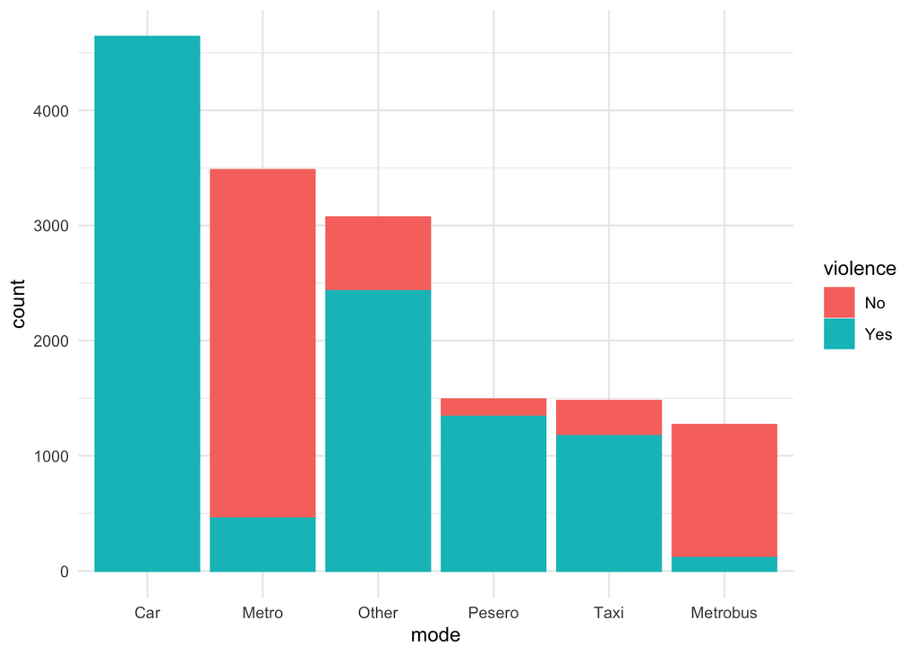

```r
transport_victims %>% select(mode, violence, datetime) %>%
                      mutate(mode = factor(mode, levels=rev(mode_levels))) %>%
                      filter(!is.na(mode)) %>%
                      ggplot(aes(x=mode, color = violence, fill = violence)) +
                      geom_bar() +
                      #geom_text(stat = "count", aes(label = ..count.., y = ..count..),position=position_stack(0.5)) +
                      theme(axis.text.x = element_text(angle = 30)) +
                      theme_minimal()
```

```r
#transport_victims <- transport_victims %>% st_as_sf(coords = c("lon", "lat"), crs = 4326)
```